# Multivariate Time Series

Maxim Anisimov, Garik Vardanyan

11/24/2018

```r
plot.varfevd  <-function (x, plot.type = c("multiple", "single"), names = NULL,
    main = NULL, col = NULL, ylim = NULL, ylab = NULL, xlab = NULL,
    legend = NULL, names.arg = NULL, nc, mar = par("mar"), oma = par("oma"),
    addbars = 1, ...)
{
    K <- length(x)
    ynames <- names(x)
    plot.type <- match.arg(plot.type)
    if (is.null(names)) {
        names <- ynames
    }
    else {
        names <- as.character(names)
        if (!(all(names %in% ynames))) {
            warning("\nInvalid variable name(s) supplied, using first variable.\n")
            names <- ynames[1]
        }
    }
    nv <- length(names)
#    op <- par(no.readonly = TRUE)
    ifelse(is.null(main), main <- paste("FEVD for", names), main <- rep(main,
        nv)[1:nv])
    ifelse(is.null(col), col <- gray.colors(K), col <- rep(col,
        K)[1:K])
    ifelse(is.null(ylab), ylab <- rep("Percentage", nv), ylab <- rep(ylab,
        nv)[1:nv])
    ifelse(is.null(xlab), xlab <- rep("Horizon", nv), xlab <- rep(xlab,
        nv)[1:nv])
    ifelse(is.null(ylim), ylim <- c(0, 1), ylim <- ylim)
    ifelse(is.null(legend), legend <- ynames, legend <- legend)
    if (is.null(names.arg))
        names.arg <- c(paste(1:nrow(x[[1]])), rep(NA, addbars))
    plotfevd <- function(x, main, col, ylab, xlab, names.arg,
        ylim, ...) {
        addbars <- as.integer(addbars)
        if (addbars > 0) {
            hmat <- matrix(0, nrow = K, ncol = addbars)
            xvalue <- cbind(t(x), hmat)
            barplot(xvalue, main = main, col = col, ylab = ylab,
                xlab = xlab, names.arg = names.arg, ylim = ylim,
                legend.text = legend, ...)
            abline(h = 0)
        }
        else {
            xvalue <- t(x)
            barplot(xvalue, main = main, col = col, ylab = ylab,
                xlab = xlab, names.arg = names.arg, ylim = ylim,
                ...)
            abline(h = 0)
        }
    }
    if (plot.type == "single") {
#        par(mar = mar, oma = oma)
#        if (nv > 1)
#            par(ask = TRUE)
        for (i in 1:nv) {
            plotfevd(x = x[[names[i]]], main = main[i], col = col,
                ylab = ylab[i], xlab = xlab[i], names.arg = names.arg,
                ylim = ylim, ...)
        }
    }
    else if (plot.type == "multiple") {
        if (missing(nc)) {
            nc <- ifelse(nv > 4, 2, 1)
        }
        nr <- ceiling(nv/nc)
        par(mfcol = c(nr, nc), mar = mar, oma = oma)
        for (i in 1:nv) {
            plotfevd(x = x[[names[i]]], main = main[i], col = col,
                ylab = ylab[i], xlab = xlab[i], names.arg = names.arg,
                ylim = ylim, ...)
        }
    }
#    on.exit(par(op))
}
```

For forecasting multivariate time series we have decided to choose UK data of:  
1. GDP (Gross Domestic Product)  
2. CPI (Consumer Price Index)  
3. 10-year government bond yield spread between 10-year and 3-month UK government bonds.

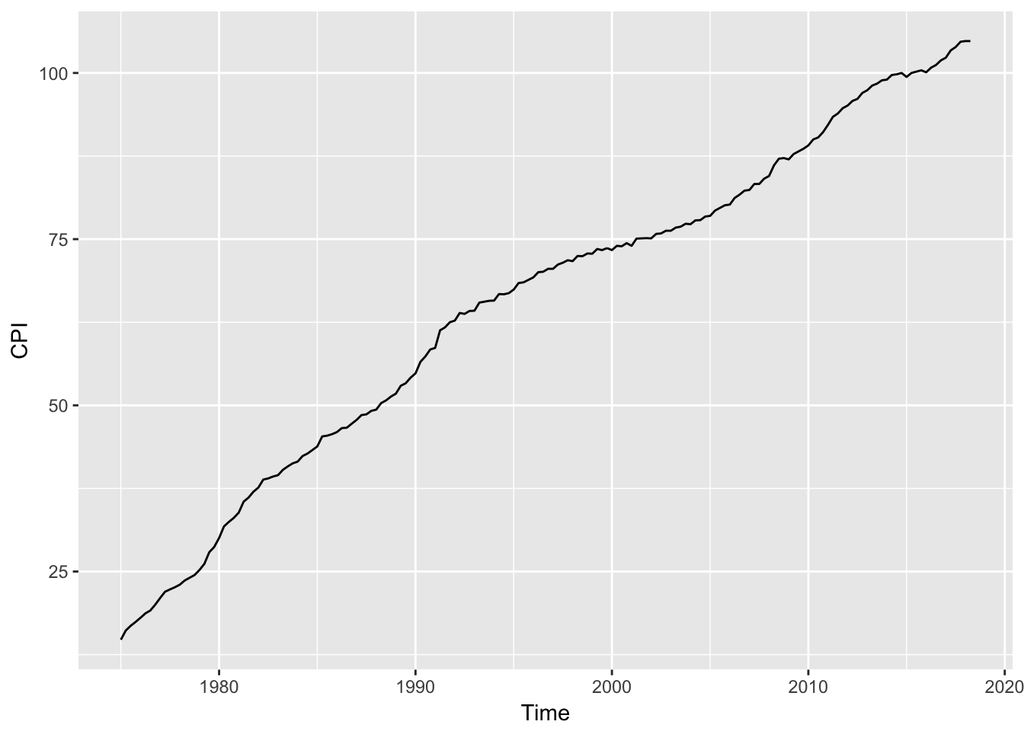

As we can see from plot of CPI the Variance is stabilized and therefore there is no need to do Box transformation.

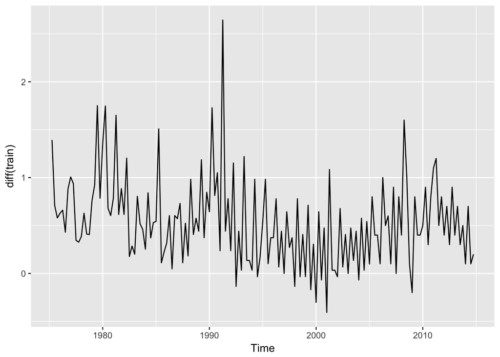

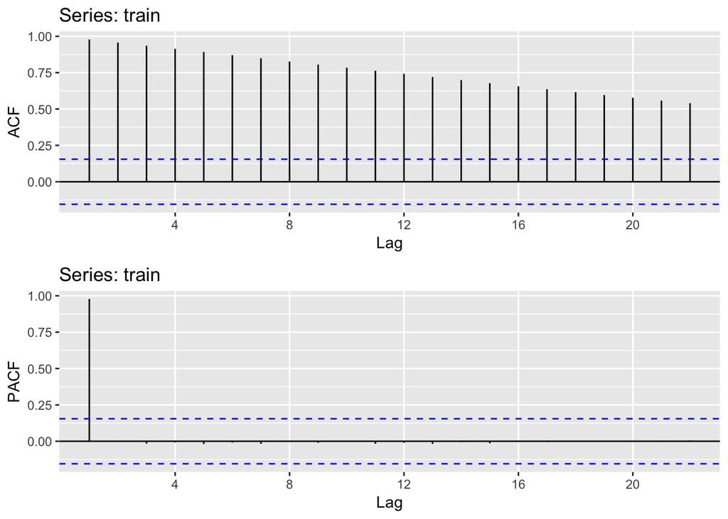

Because ACF of data is slowly decreasing we can see that there is a sign of unit root in our series. The PACF also indicates unit root.

```
##
##  Augmented Dickey-Fuller Test
##
## data:  train
## Dickey-Fuller = -2.2476, Lag order = 4, p-value = 0.4731
## alternative hypothesis: stationary
```

```
##
##  Augmented Dickey-Fuller Test
##
## data:  diff(train)
## Dickey-Fuller = -3.6919, Lag order = 4, p-value = 0.02708
## alternative hypothesis: stationary
```

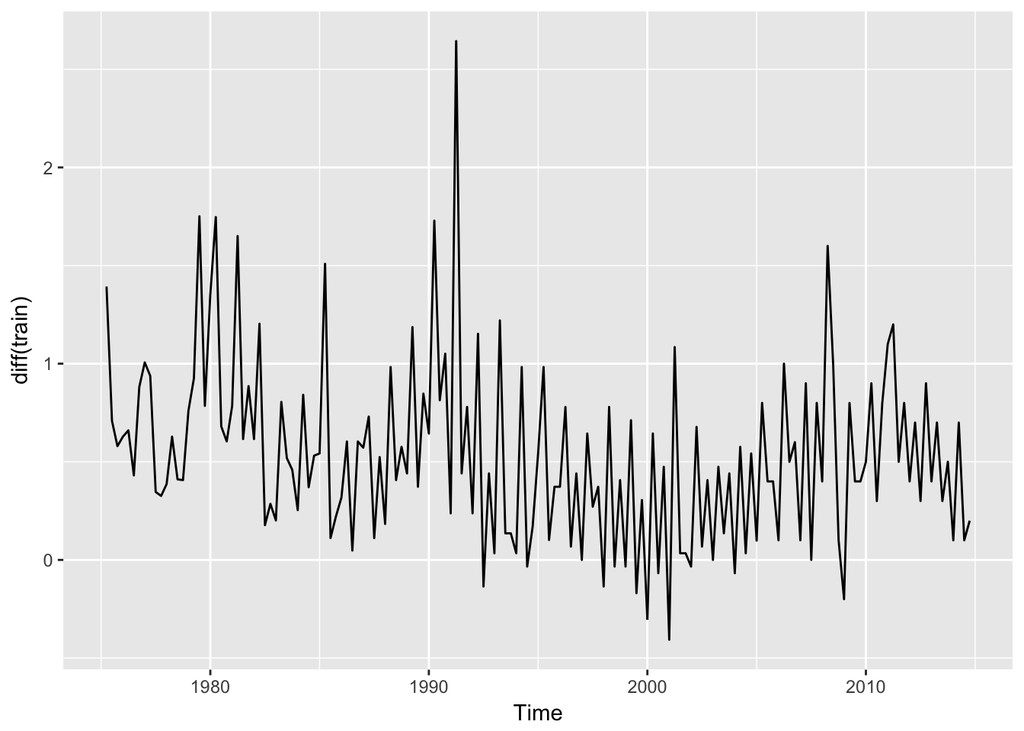

```
## Series: train
## ARIMA(0,2,1)(0,0,2)[4]
##
## Coefficients:
##           ma1    sma1    sma2
##       -0.9464  0.4625  0.2782
## s.e.   0.0364  0.0810  0.0789
##
## sigma^2 estimated as 0.1367:  log likelihood=-66.77
## AIC=141.53   AICc=141.79   BIC=153.78
##
## Training set error measures:
##                       ME      RMSE       MAE        MPE      MAPE
## Training set -0.02811179 0.3639096 0.2827576 -0.0827739 0.5740376
##                   MASE       ACF1
## Training set 0.1323144 0.08445782
```

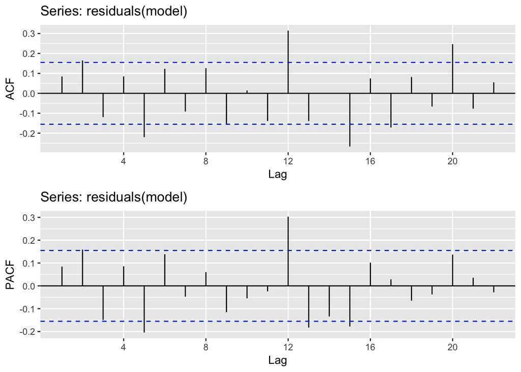

Auto Arima suggests that our data is second order difference stationary. It computes that ARIMA(0,2,1) is the optimal choice for our data. ACF and PACF of residuals suggest that residuals are not White Noise. Now we will do Ljung-Box test to be sure that residuals are not White Noise.

```
##
##  Box-Ljung test
##
## data:  residuals(model)
## X-squared = 9.1612, df = 1, p-value = 0.002472
```

We get that null hypothesis can be rejected and there are not WN residuals in our model.

```r
a <- rep(0, times = 25)
A <- matrix(a, nrow = 5)
for (i in 1:5) {
  for (j in 1:5) {
    model <-  Arima(train, order = c(i-1,2,j-1))
    A[i,j] <- model$aicc
  }
}

a <- rep(0, times = 25)
B <- matrix(a, nrow = 5)
for (i in 1:5) {
  for (j in 1:5) {
    model <-  Arima(train, order = c(i-1,1,j-1))
    B[i,j] <- model$aicc
  }
}
A
```

```
##          [,1]     [,2]     [,3]     [,4]      [,5]
## [1,] 309.4964 193.4648 187.1157 188.5248 181.13150
## [2,] 213.8175 184.9823 143.2963 138.7581 136.41232
## [3,] 213.2351 184.2129 142.5545 139.4673 138.42028
## [4,] 125.9165 118.0347 120.0625 122.2280  99.75129
## [5,] 119.7829 118.5357 115.4538 117.5260  96.92357
```

```r
B
```

```
##          [,1]     [,2]     [,3]     [,4]     [,5]
## [1,] 340.6090 315.2763 266.0271 265.4099 201.6962
## [2,] 277.5553 197.2003 190.1324 191.8229 182.0970
## [3,] 210.2663 185.6511 146.7009 142.6163 139.5379
## [4,] 211.2008 187.9258 146.3092 143.2661 141.4608
## [5,] 128.6806 120.3319 122.4701 118.2027 102.6764
```

Looking at different set of parameters we get that best model is Arima(4,2,4), now lets fit this model. We will try also other models Arima(4,1,4) and Arima(3,2,4) that have AIC close to 102, maybe in test data this models will be better,

```r
model <-  Arima(train, order = c(4,2,4))
summary(model)
```

```
## Series: train
## ARIMA(4,2,4)
##
## Coefficients:
##           ar1      ar2      ar3     ar4      ma1     ma2     ma3      ma4
##       -0.5230  -0.5330  -0.5391  0.4356  -0.1807  0.1992  0.0264  -0.7029
## s.e.   0.1707   0.1638   0.1697  0.1622   0.1524  0.0897  0.1304   0.0864
##
## sigma^2 estimated as 0.09753:  log likelihood=-38.85
## AIC=95.71   AICc=96.92   BIC=123.27
##
## Training set error measures:
##                       ME      RMSE       MAE        MPE      MAPE
## Training set -0.02025474 0.3023753 0.2256717 -0.0641085 0.4614141
##                   MASE        ACF1
## Training set 0.1056014 -0.01254165
```

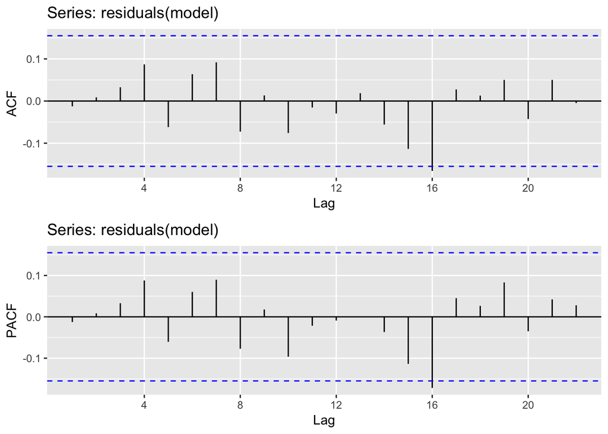

```r
grid.arrange(ggAcf(residuals(model)),ggPacf(residuals(model)))
```

```r
Box.test(residuals(model),lag =4, fitdf = 3,type = 'Ljung')
```

```
##
##  Box-Ljung test
##
## data:  residuals(model)
## X-squared = 1.4721, df = 1, p-value = 0.225
```

```r
model1 <-Arima(train, order = c(4,1,4))
summary(model1)
```

```
## Series: train
## ARIMA(4,1,4)
##
## Coefficients:
##          ar1      ar2      ar3     ar4     ma1     ma2     ma3      ma4
##       0.0077  -0.0138  -0.0289  0.9679  0.2253  0.3726  0.3380  -0.5179
## s.e.  0.0204   0.0188   0.0202  0.0196  0.0891  0.0882  0.0905   0.0955
##
## sigma^2 estimated as 0.1001:  log likelihood=-41.73
## AIC=101.47   AICc=102.68   BIC=129.09
##
## Training set error measures:
##                     ME      RMSE       MAE        MPE      MAPE      MASE
## Training set 0.0163997 0.3074101 0.2259459 0.04311955 0.4748115 0.1057297
##                    ACF1
## Training set 0.04295844
```

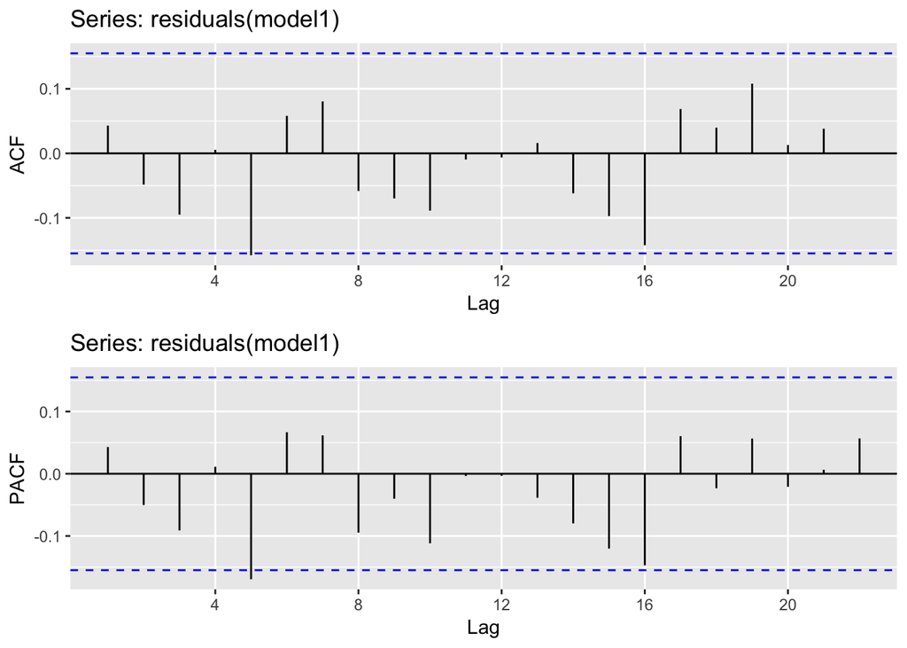

```r
grid.arrange(ggAcf(residuals(model1)),ggPacf(residuals(model1)))
```

```r
Box.test(residuals(model1),lag =4, fitdf = 3,type = 'Ljung')
```

```
##
##  Box-Ljung test
##
## data:  residuals(model1)
## X-squared = 2.1796, df = 1, p-value = 0.1398
```

```r
model2 <-Arima(train, order = c(3,2,4))
summary(model2)
```

```
## Series: train
## ARIMA(3,2,4)
##
## Coefficients:
##           ar1      ar2      ar3     ma1     ma2     ma3      ma4
##       -0.9751  -0.9726  -0.9849  0.2055  0.3545  0.3185  -0.5382
## s.e.   0.0145   0.0168   0.0124  0.0841  0.0834  0.0862   0.0899
##
## sigma^2 estimated as 0.1003:  log likelihood=-41.39
## AIC=98.78   AICc=99.75   BIC=123.29
##
## Training set error measures:
##                       ME     RMSE       MAE         MPE      MAPE
## Training set -0.01545949 0.307593 0.2284952 -0.04979528 0.4750184
##                   MASE       ACF1
## Training set 0.1069227 0.07308724
```

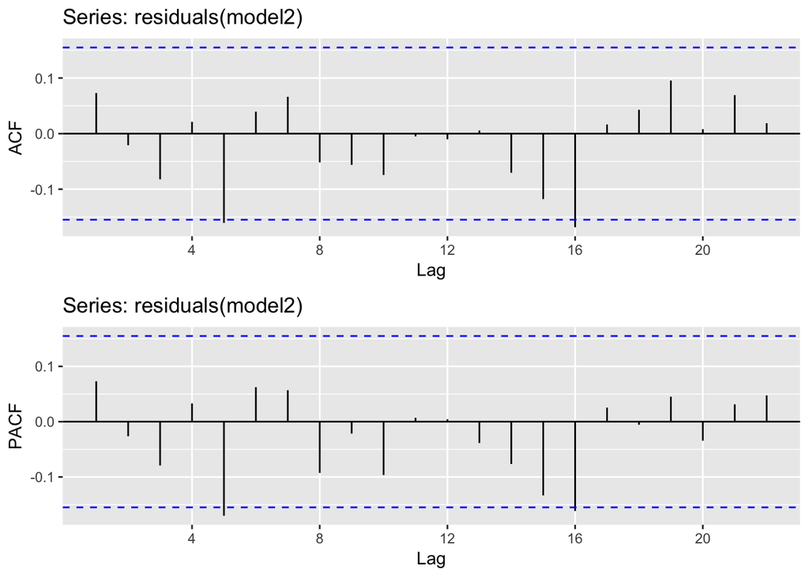

```r
grid.arrange(ggAcf(residuals(model2)),ggPacf(residuals(model2)))
```

```r
Box.test(residuals(model2),lag =4, fitdf = 3,type = 'Ljung')
```

```
##
##  Box-Ljung test
##
## data:  residuals(model2)
## X-squared = 2.1339, df = 1, p-value = 0.1441
```

We get that null hypothesis can not be rejected and there are WN residuals in our model.

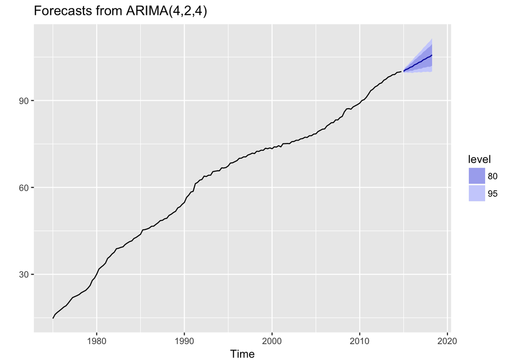

```
##
##  Jarque Bera Test
##
## data:  residuals(model)
## X-squared = 154.84, df = 2, p-value < 2.2e-16
```

```
##
##  Shapiro-Wilk normality test
##
## data:  residuals(model)
## W = 0.92958, p-value = 4.541e-07
```

```r
jarque.bera.test(residuals(model1))
```

```
##
##  Jarque Bera Test
##
## data:  residuals(model1)
## X-squared = 83.985, df = 2, p-value < 2.2e-16
```

```r
shapiro.test(residuals(model1))
```

```
##
##  Shapiro-Wilk normality test
##
## data:  residuals(model1)
## W = 0.94925, p-value = 1.553e-05
```

```r
jarque.bera.test(residuals(model2))
```

```
##
##  Jarque Bera Test
##
## data:  residuals(model2)
## X-squared = 78.456, df = 2, p-value < 2.2e-16
```

```r
shapiro.test(residuals(model2))
```

```
##
##  Shapiro-Wilk normality test
##
## data:  residuals(model2)
## W = 0.95213, p-value = 2.758e-05
```

We get from Jarque-Bera test and Shapiro test that our residuals are not normally distributed for all of our models, therefore confidence intervals are not correctly built. Now we will check accuracy of our model.

```r
accuracy(forec,test)
```

```
##                       ME      RMSE       MAE        MPE      MAPE
## Training set -0.02025474 0.3023753 0.2256717 -0.0641085 0.4614141
## Test set     -0.90345141 1.0015981 0.9034514 -0.8902259 0.8902259
##                   MASE        ACF1 Theil's U
## Training set 0.1056014 -0.01254165        NA
## Test set     0.4227635  0.75948410   1.86993
```

```r
test <- window(CPI, start=c(2013, 1))

fore_arima_424 <- function(y, h) {
  model <- Arima(y, order = c(4,2, 4))
  forecast <- forecast(model, h)
  return(forecast)
}

errors_cv <- tsCV(test, fore_arima_424, h = 1)
forecaster <- errors_cv + test

accuracy(forecaster,test)
```

```
##                  ME      RMSE       MAE        MPE      MAPE       ACF1
## Test set 0.02800712 0.5307958 0.4662891 0.02495764 0.4582358 0.02907093
##          Theil's U
## Test set  0.827263
```

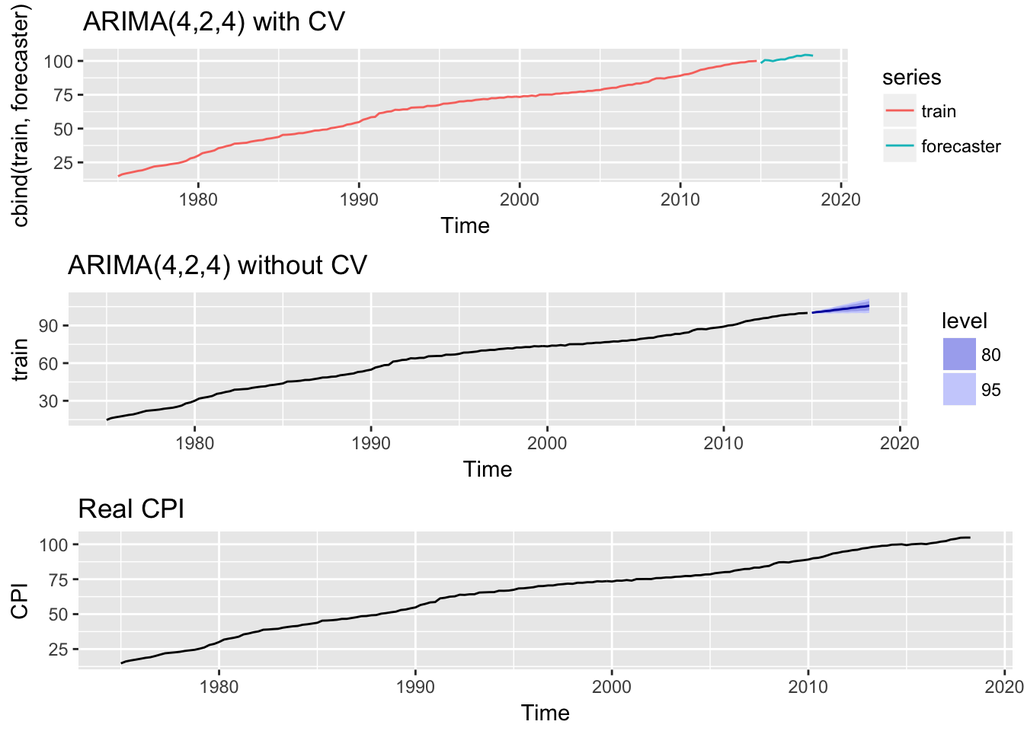

```r
plot1 <- autoplot(cbind(train,forecaster))+ggtitle("ARIMA(4,2,4) with CV")
plot2 <-autoplot(forecast(model, h=14))+ggtitle("ARIMA(4,2,4) without CV")
plot3 <-autoplot(CPI)+ggtitle("Real CPI")
grid.arrange(plot1,plot2,plot3,nrow = 3)
```

Obviously, cross validation with h = 1 works better than our initial model, as our data have in this case more information and doesn’t forecast for 14 periods future. Note that we changed test in last step because we take difference and inside cross validation this first 2 of test will be NAN.

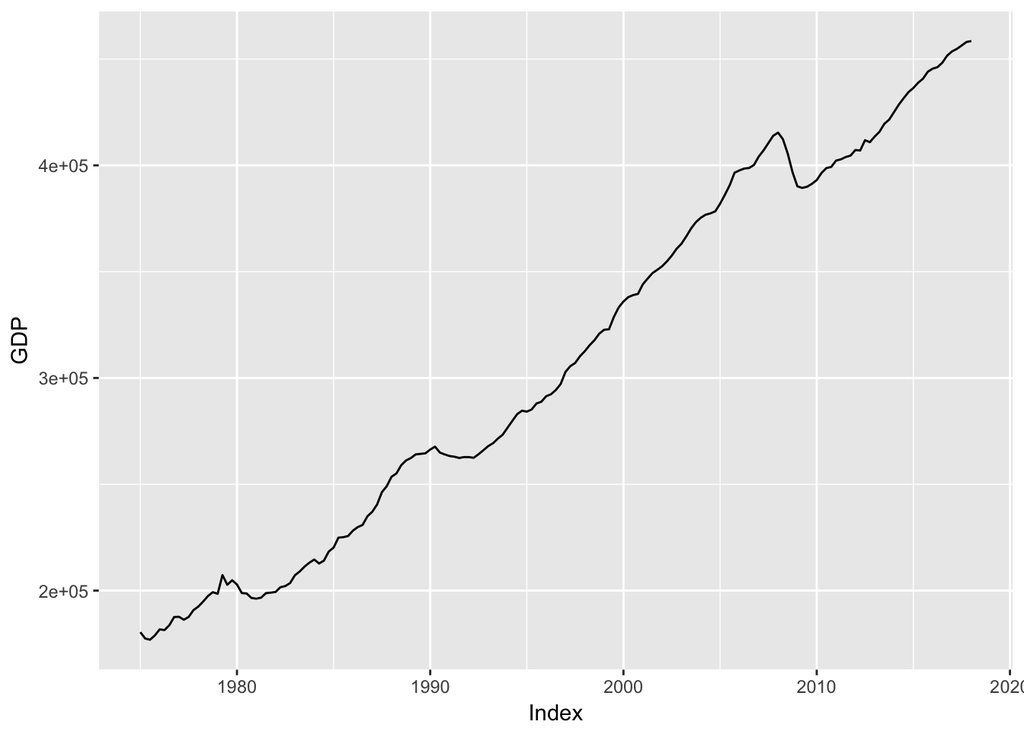

```r
GDP <- import('/Users/garik/Desktop/Time Series Homework/Real_GDP-2.csv')
CPI <- import('/Users/garik/Desktop/Time Series Homework/CPI-2.csv')
BondYield10Y <- import('/Users/garik/Desktop/Time Series Homework/Bond_Yield_10Y-2.csv')
BondYield3M <- import('/Users/garik/Desktop/Time Series Homework/yield3_2.csv')

BondYield3M$Yield <- as.numeric(BondYield3M$Yield)
colnames(BondYield3M)[1] <- 'DATE'

GDP$DATE <- as.Date(GDP$DATE,"%d/%m/%Y")
CPI$DATE <- as.Date(CPI$DATE,"%d/%m/%Y")
BondYield10Y$DATE <- as.Date(BondYield10Y$DATE, "%Y-%m-%d")
BondYield3M$DATE <- as.Date(seq(as.Date('1975-01-01'), as.Date('2018-04-01'), by = "quarter"), "%Y-%m-%d")

CPI_1 <- CPI %>% filter(DATE >= GDP$DATE[1])
BondYield10Y_1 <- BondYield10Y %>% filter(DATE >= GDP$DATE[1])
BondYield3M_1 <- BondYield3M %>% filter(DATE >= GDP$DATE[1])

BondYield10Y_1$YearQ <- quarter(BondYield10Y_1$DATE, with_year = T)
BondYield10Y_2 <- aggregate(IRLTLT01GBM156N ~ YearQ, BondYield10Y_1, mean)
BondYield10Y_2$DATE <- seq(BondYield10Y_1$DATE[1], BondYield10Y_1$DATE[nrow(BondYield10Y_1)], by = "quarter")
BondYield10Y_2 <- BondYield10Y_2[, c('DATE', 'IRLTLT01GBM156N')]
BondYield10Y_2 <- BondYield10Y_2 %>% filter(DATE <= '2018-04-01')

BondYieldSpread <- BondYield10Y_2 - BondYield3M_1
BondYieldSpread$DATE <- BondYield10Y_2$DATE

all_data <- Reduce(function(...) merge(..., all=TRUE), list(GDP, CPI_1, BondYieldSpread))
colnames(all_data) <- c('Date', 'GDP', 'CPI', 'BondYieldSpread')

data <- all_data %>% filter(Date <= '2018-01-01')

ts_data <- to.quarterly(xts(data[,-1], order.by=as.Date(data[,1], "%m/%d/%Y")), OHLC=F)
autoplot(ts_data$GDP)
```